```r
# setup, include=FALSE
knitr::opts_chunk$set(echo = TRUE)
```

# Ask - determine task

This is a report about choosing which marketing strategy has the best probability to convert most of the casual users into annual subscribers.

```r
# removing var
rm(list=ls())
```

```r
# import library + dataset,echo=FALSE, warning=FALSE
library(tidyverse)
tripsq <- read.csv("Divvy_Trips_2020_Q1.csv")
```

# Prepare - get data

I used the dataset from the first quarter of year 2020, as it was the most recent data available The license makes it so that I can complete the analysis without any problems The data has no problems in itself as it’s internal data from the company.

```r
# view the dataset
colnames(tripsq)
```

```
##  [1] "ride_id"            "rideable_type"      "started_at"
##  [4] "ended_at"           "start_station_name" "start_station_id"
##  [7] "end_station_name"   "end_station_id"     "start_lat"
## [10] "start_lng"          "end_lat"            "end_lng"
## [13] "member_casual"
```

```r
view(tripsq)
```

# Process - clean and fix and filter

There are two columns that are formatted wrongly.

for the analysis, I don’t need: start_lng ,start_lat, end_lat, end_lng = It’s langtitude and altitude. rideable_type = all data is docked_bike.

```r
# removing non wanted columns
# dropping long & alt cols
tripcld1 <- subset(tripsq, select=-c(start_lat, end_lat, start_lng, end_lng))
# check
colnames(tripcld1)
```

```
## [1] "ride_id"            "rideable_type"      "started_at"
## [4] "ended_at"           "start_station_name" "start_station_id"
## [7] "end_station_name"   "end_station_id"     "member_casual"
```

```r
# fix start at - end at
#check type: class(tripcld1[3,2]) = character
start_fix <- as_datetime(tripcld1$started_at)
end_fix <- as_datetime(tripcld1$ended_at)
# check type:
class(end_fix)
```

```
## [1] "POSIXct" "POSIXt"
```

```r
# adding start_fix as a new col, and dropping the old one
tripcld2 <- cbind(tripcld1, started_at_fix = start_fix)
tripcld3 <- cbind(tripcld2, ended_at_fix = end_fix)
# change validation:
class(tripcld3$ended_at_fix)
```

```
## [1] "POSIXct" "POSIXt"
```

```r
# dropping old start-end
tripcld4 <- subset(tripcld3, select=-c(started_at, ended_at))
# check with colnames:
colnames(tripcld4)
```

```
## [1] "ride_id"            "rideable_type"      "start_station_name"
## [4] "start_station_id"   "end_station_name"   "end_station_id"
## [7] "member_casual"      "started_at_fix"     "ended_at_fix"
```

```r
# check class
class(tripcld4$started_at_fix)
```

```
## [1] "POSIXct" "POSIXt"
```

```r
class(tripcld4$ended_at_fix)
```

```
## [1] "POSIXct" "POSIXt"
```

Adding trip_duration

```r
# adding trip_duartion and defining it
tripcld5 <- cbind(tripcld4, trip_duration = tripcld4$ended_at_fix - tripcld4$started_at_fix)
# check names-values-class
colnames(tripcld5)
```

```
##  [1] "ride_id"            "rideable_type"      "start_station_name"
##  [4] "start_station_id"   "end_station_name"   "end_station_id"
##  [7] "member_casual"      "started_at_fix"     "ended_at_fix"
## [10] "trip_duration"
```

```r
head(tripcld5$trip_duration)
```

```
## Time differences in secs
## [1] 451 223 171 529 332 289
```

```r
class(tripcld5$trip_duration)
```

```
## [1] "difftime"
```

Checking for Duplicates

```r
# check for duplicates
length(unique(tripcld5$ride_id)) == nrow(tripcld5)
```

```
## [1] TRUE
```

```r
# No duplicates
dim(tripcld5[duplicated(tripcld5$ride_id),])[1]
```

```
## [1] 0
```

```r
# Another to check -from stackoverflow
```

Checking for nulls

```r
# check for nulls
is.null(tripcld5)
```

```
## [1] FALSE
```

```r
# No Nulls!
```

Adding Weekday Column

```r
# add weekdays
weekday <- weekdays(tripcld5$started_at_fix)
tripcld6 <- cbind(tripcld5, weekday = weekday)
# check
colnames(tripcld6)
```

```
##  [1] "ride_id"            "rideable_type"      "start_station_name"
##  [4] "start_station_id"   "end_station_name"   "end_station_id"
##  [7] "member_casual"      "started_at_fix"     "ended_at_fix"
## [10] "trip_duration"      "weekday"
```

```r
class(tripcld6$weekday)
```

```
## [1] "character"
```

```r
view(tripcld6$weekday)
```

Checking the data types of the dataset

```r
# check datatype - final
str(tripcld6)
```

```
## 'data.frame':    426887 obs. of  11 variables:
##  $ ride_id           : chr  "EACB19130B0CDA4A" "8FED874C809DC021" "789F3C21E472CA96" "C9A388DAC6ABF313" ...
##  $ rideable_type     : chr  "docked_bike" "docked_bike" "docked_bike" "docked_bike" ...
##  $ start_station_name: chr  "Western Ave & Leland Ave" "Clark St & Montrose Ave" "Broadway & Belmont Ave" "Clark St & Randolph St" ...
##  $ start_station_id  : int  239 234 296 51 66 212 96 96 212 38 ...
##  $ end_station_name  : chr  "Clark St & Leland Ave" "Southport Ave & Irving Park Rd" "Wilton Ave & Belmont Ave" "Fairbanks Ct & Grand Ave" ...
##  $ end_station_id    : int  326 318 117 24 212 96 212 212 96 100 ...
##  $ member_casual     : chr  "member" "member" "member" "member" ...
##  $ started_at_fix    : POSIXct, format: "2020-01-21 20:06:59" "2020-01-30 14:22:39" ...
##  $ ended_at_fix      : POSIXct, format: "2020-01-21 20:14:30" "2020-01-30 14:26:22" ...
##  $ trip_duration     : 'difftime' num  451 223 171 529 ...
##   ..- attr(*, "units")= chr "secs"
##  $ weekday           : chr  "Tuesday" "Thursday" "Thursday" "Monday" ...
```

```r
# it's fine!
```

Drop every entry with trip_duration less than 0

```r
# drop length less than 0,echo=FALSE, warning=FALSE
tripcld7 <- filter(tripcld6, trip_duration > 0)
```

Defining a subset for casuals and members

```r
# dataset casual & member
tripcasual <- filter(tripcld7, member_casual == "casual")
tripcasual <-subset(tripcasual, select=-c(member_casual, rideable_type, end_station_id, start_station_id, ride_id))
tripmember <- filter(tripcld7, member_casual == "member")
tripmember <- subset(tripmember, select=-c(member_casual, rideable_type, end_station_id, start_station_id, ride_id))
```

# Analyze - find out what’s happening

```r
# mean & max & median of ride length,echo=FALSE, warning=FALSE
mean_max_median_all <- summarise(tripcld7, mean_ride = mean(trip_duration), max_ride_ = max(trip_duration), median_ride = median(trip_duration), min_ride = min(trip_duration))

mean_max_median_member <- summarise(tripmember, mean_ride = mean(trip_duration), max_ride_ = max(trip_duration), median_ride = median(trip_duration), min_ride = min(trip_duration))

mean_max_median_casual <- summarise(tripcasual, mean_ride = mean(trip_duration), max_ride_ = max(trip_duration), median_ride = median(trip_duration), min_ride = min(trip_duration))
```

Finding AVG trip_duration

```r
# avg trip duration by weekday & membership
# need to: sum trip duration by weekday, so 2 aggregations => basic aggregate
tripduagg <- aggregate(tripcld7$trip_duration ~ tripcld7$member_casual + tripcld7$weekday,FUN=mean) # %>% view()
# works
```

Finding the number of trips per day

```r
# count trips per day
trippday <- count(tripcld7, weekday) #%>%  view
# works
# add member_casual for distinct between members&casuals
```

# Share - visuals

Viz1: AVG number of rider per day per member type

[figure not shown]

```r
# viz rides number per member
tripcld7 %>%
  group_by(member_casual, weekday) %>%
  summarise(number_of_rides = n() ,average_duration = mean(trip_duration)) %>%
  arrange(member_casual, weekday)  %>%
  ggplot(aes(x = weekday, y = number_of_rides, fill = member_casual)) +
  geom_col(position = "dodge")+
  labs(x="Weekday", y="Average Trip Duration by Second") +
  guides(fill=guide_legend(title="Member or Casual"))+
  theme(axis.text.x = element_text(angle = 45,hjust=1))
```

```r
# ggsave("ride_per_member.png")
```

Viz2: AVG trip_duration per day per member type

```
## Defaulting to continuous.
```

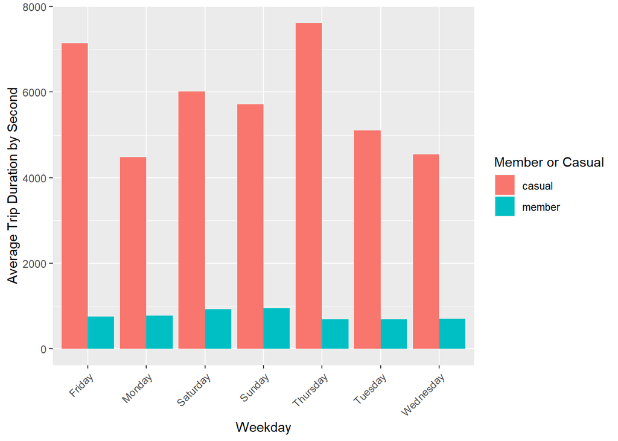

```r
# viz ride duration per member
tripcld7 %>%
  group_by(member_casual, weekday) %>%
  summarise(number_of_rides = n() ,average_duration = mean(trip_duration)) %>%
  arrange(member_casual, weekday)  %>%
  ggplot(aes(x = weekday, y = average_duration, fill = member_casual)) +
  geom_col(position = "dodge") +
  labs(x="Weekday", y="Average Trip Duration by Second") +
  guides(fill=guide_legend(title="Member or Casual"))+
  theme(axis.text.x = element_text(angle = 45,hjust=1))
```

```r
# ggsave("duration_per_member.png")
```

# Act - what to do

- It seems that members tend to take shorter trips than casual riders, but more in quantity.

This could be because members are more likely to use the bikes for commuting to work or school, while casual riders are more likely to use the bikes for leisure activities.

To convert more casual riders into members, we can:

- Consider offering incentives to casual riders who use the bikes for commuting to work or school.
- Promote the **benefits** of membership to casual users, such as access to *more* rides and *discounts* on equipment rentals.
- Focus on marketing campaigns that target *weekday* riders, as this is where the biggest difference between members and casual users is seen.
- Explore ways to encourage members to take *longer* rides, such as offering **special rewards** or **discounts** for *longer* trips.